# kirichenko_hw2

### Машинное Обучения

## Домашнее задание №2 - Дерево решений

**Общая информация**

**Срок сдачи:** 1 февраля 2023, 08:30  
**Штраф за опоздание:** -2 балла за каждые 2 дня опоздания

Решений залить в свой github репозиторий.

Используйте данный Ipython Notebook при оформлении домашнего задания.

## Реализуем дерево решений (3 балла)

Допишите недостающие части дерева решений. Ваша реализация дерева должна работать по точности не хуже DecisionTreeClassifier из sklearn. Внимание: если Вас не устраивает предложенная структура хранения дерева, Вы без потери баллов можете сделать свой класс MyDecisionTreeClassifier, в котором сами полностью воспроизведете алгоритм дерева решений. Обязательно в нем иметь только функции fit, predict . (Но название класса не менять)

```python
import matplotlib.pyplot as plt
import numpy as np
import pandas as pd

from sklearn.datasets import load_wine
from sklearn.ensemble import RandomForestClassifier
from sklearn.metrics import accuracy_score
from sklearn.model_selection import KFold, train_test_split, GridSearchCV, RandomizedSearchCV
from sklearn.tree import DecisionTreeClassifier
import warnings
warnings.filterwarnings("ignore")
```

```python
from collections import defaultdict

class MyDecisionTreeClassifier:
    NON_LEAF_TYPE = 0
    LEAF_TYPE = 1

    def __init__(self, min_samples_split=2, max_depth=5, criterion='entropy', faster = False):
        """
        criterion -- критерий расщепления. необходимо релизовать три:
        Ошибка классификации, Индекс Джини, Энтропийный критерий
        max_depth -- максимальная глубина дерева
        min_samples_split -- минимальное число объектов в листе, чтобы сделать новый сплит
        """
        self.min_samples_split = min_samples_split
        self.max_depth = max_depth
        self.num_class = -1
        # Для последнего задания
        self.feature_importances_ = None
        criterions = {'gini' : self.__gini,
                          'entropy' : self.__entropy,
                           'misclass': self.__misclass}
        self.criterion = criterions[criterion]
        # Структура, которая описывает дерево
        # Представляет словарь, где для  node_id (айдишник узла дерева) храним
        # (тип_узла, айдишник признака сплита, порог сплита) если тип NON_LEAF_TYPE
        # (тип_узла, предсказание класса, вероятность класса) если тип LEAF_TYPE
        # Подразумевается, что у каждого node_id в дереве слева
        # узел с айди 2 * node_id + 1, а справа 2 * node_id + 2
        self.tree = dict()
        self.faster = faster

    def __div_samples(self, x, y, feature_id, threshold):
        """
        Разделяет объекты на 2 множества
        x -- матрица объектов
        y -- вектор ответов
        feature_id -- айдишник признака, по которому делаем сплит
        threshold -- порог, по которому делаем сплит
        """
        left_mask = x[:, feature_id] > threshold
        right_mask = ~left_mask
        return x[left_mask], x[right_mask], y[left_mask], y[right_mask]

    def __misclass(self, y):
        prob = np.bincount(y)/y.shape
        return 1 - np.max(prob)


    def __entropy(self, y):
        # prob mojet bit' 0, poetomu +1e-10
        prob = np.bincount(y)/y.shape
        return -(prob * np.log(prob + 1e-10)).sum()


    def __gini(self, y):
        p = np.bincount(y)/y.shape
        if not p.shape[0]:
            return 1
        return (p* (1 - p)).sum()


    def __ma(self, x, window = 2):
      return np.convolve(x, np.ones(window), 'valid') / window




    def __find_thresholdBrootForce(self, x, y):
        best_feature, best_Q, best_threshold = -1, -1, -1
        obj, features = x.shape
        for feature in range(features):
          cols = x[:, feature]
          cols = self.__ma(cols)
          for value in cols:
            x_l, x_r, y_l, y_r = self.__div_samples(x, y, feature, value)
            if y_l.shape[0]:
              Q = self.criterion(y) - (y_l.shape[0] / y.shape[0]) * self.criterion(y_l) - (y_r.shape[0] / y.shape[0]) * self.criterion(y_r)

              if Q > best_Q:
                best_Q = Q
                best_feature = feature
                best_threshold = value
        return best_feature, best_threshold


    def __sort_samples(self, x ,y ):
        sorted_args = x.argsort()
        return x[sorted_args], y[sorted_args]


    def __fast_entropy(self, leftCounts,leftS , rightCounts, rightS):
         p1 = leftS * (-((leftCounts / leftS) * np.log( (leftCounts + 1e-10)/ leftS)).sum(axis = 1)).reshape(-1, 1)
         p2 = rightS * (-((rightCounts / rightS) * np.log(
               (rightCounts + 1e-10)/ rightS)).sum(axis = 1)).reshape(-1, 1)
         return (p1 + p2) / (leftS + rightS)








    def __find_threshold(self, x, y):


        x_sort, y_sort = self.__sort_samples(x, y)
        split_cut = self.min_samples_split
        y_split = y_sort
        #обрезаем вектор ответов
        if split_cut:
            y_split = y_sort[split_cut:-split_cut]
        class_bound = np.where(y_split[:-1] != y_split[1:])[0] + (split_cut + 1)

        if len(class_bound) == 0:
            return np.inf, None

        eq_el_count = class_bound - np.append([split_cut], class_bound[:-1])
        OneHotMatrix = np.zeros((class_bound.shape[0], self.num_class))
        OneHotMatrix[np.arange(class_bound.shape[0]), y_sort[class_bound - 1]] = 1
        classInc = OneHotMatrix * eq_el_count.reshape(-1, 1)
        classInc[0] = classInc[0] + np.bincount(y_sort[:split_cut], minlength = self.num_class)

        l_c = np.cumsum(classInc, axis=0)
        r_c = np.bincount(y_sort, minlength = self.num_class) - l_c
        l_s = class_bound.reshape(l_c.shape[0], 1)
        r_s = y_sort.shape[0] - l_s
        Q = self.__fast_entropy(l_c, l_s, r_c, r_s)
        #Т.к H для всех элементов не зависит от вектора, => задача максимизации превращается в задачу минимизации
        feature = np.argmin(Q)
        left_el_id = l_s[feature][0]
        #Возвращаем Moving Average с окном 2
        return Q[feature], (x_sort[left_el_id - 1] + x_sort[left_el_id]) / 2.0






    def checkLeaf(self, y, depth):
        return (self.max_depth <= depth) or \
               (y.size < self.min_samples_split)

    def __fit_node(self, x, y, node_id, depth):
        if self.checkLeaf(y, depth):
            self.tree[node_id] = [self.__class__.LEAF_TYPE, np.argmax(np.bincount(y))]
        else:
            if self.faster:
              thresholds = np.array([self.__find_threshold(x[:, i], y)
                                    for i in range(x.shape[1])])
              best_feature = np.argmin(thresholds[:, 0])
              best_threshold = thresholds[best_feature, 1]
            else:
              best_feature, best_threshold = self.__find_thresholdBrootForce(x, y)
            if best_threshold == None:
                self.tree[node_id] = [self.__class__.LEAF_TYPE, np.argmax(np.bincount(y))]
            else:
                l_x, r_x, l_y, r_y = self.__div_samples(x, y, best_feature, best_threshold)

                if (l_x.size == 0) or (r_x.size == 0):
                    self.tree[node_id] = [self.__class__.LEAF_TYPE, np.argmax(np.bincount(y))]
                else:
                    self.tree[node_id] = [self.__class__.NON_LEAF_TYPE, best_feature, best_threshold]
                    self.__fit_node(l_x, l_y, 2 * node_id + 1, depth + 1)
                    self.__fit_node(r_x, r_y, 2 * node_id + 2, depth + 1)
                    l_s = np.array(l_y.size)
                    r_s = np.array(r_y.size)
                    c = -np.sum(np.unique(y, return_counts=True)[1] *
                                    np.log2(np.unique(y, return_counts=True)[1])) / y.size
                    l_count = -np.sum(np.unique(l_y, return_counts=True)[1] *
                                      np.log2(np.unique(l_y, return_counts=True)[1])) / l_y.size
                    r_count = -np.sum(np.unique(r_y, return_counts=True)[1] *
                                      np.log2(np.unique(r_y, return_counts=True)[1])) / r_y.size
                    self.feature_importances_[best_feature] += y.size * c - l_y.size * l_count - l_y.size * r_count



    def fit(self, x, y):
        """
        Рекурсивно строим дерево решений
        Начинаем с корня node_id 0
        """
        self.num_class = np.unique(y).size
        self.feature_importances_ = np.zeros(x.shape[1])
        self.__fit_node(x, y, 0, 0)
        self.feature_importances_ /= np.sum(self.feature_importances_)
    def __predict_class(self, x, node_id):
        """
        Рекурсивно обходим дерево по всем узлам,
        пока не дойдем до терминального
        """
        node = self.tree[node_id]
        if node[0] == self.__class__.NON_LEAF_TYPE:
            _, feature_id, threshold = node
            if x[feature_id] >= threshold:
                return self.__predict_class(x, 2 * node_id + 1)
            else:
                return self.__predict_class(x, 2 * node_id + 2)
        else:
            return node[1]

    def predict(self, X):
        """
        Вызывает predict для всех объектов из матрицы X
        """
        return np.array([self.__predict_class(x, 0) for x in X])

    def fit_predict(self, x_train, y_train, predicted_x):
        self.fit(x_train, y_train)
        return self.predict(predicted_x)

    def get_feature_importance(self):
        """
        Возвращает важность признаков
        """
        # Ваш код здесь
        return self.feature_importances_
```

```python
my_clf = MyDecisionTreeClassifier(min_samples_split=2, max_depth = 3, faster = True)
clf = DecisionTreeClassifier(min_samples_split=2)
```

```python
wine = load_wine()
X_train, X_test, y_train, y_test = train_test_split(wine.data, wine.target, test_size=0.1, stratify=wine.target, random_state = 42)
```

```python
my_clf.fit(X_train, y_train)
```

```python
accuracy_score(my_clf.predict(X_test), y_test)
```

```
1.0
```

Совет: Проверьте, что ваша реализация корректно работает с признаками в которых встречаются повторы. И подумайте, какие еще граничные случаи могут быть. Например, проверьте, что на таком примере ваша модель корректно работает:

```python
X = np.array([[1] * 10, [0, 1, 2, 5, 6, 3, 4, 7, 8, 9]]).T
y = np.array([0, 0, 0, 0, 0, 1, 1, 1, 1, 1])
for depth in range(1, 5):
    my_clf = MyDecisionTreeClassifier(max_depth=depth, faster = False)
    my_clf.fit(X, y)
    print("DEPTH:", depth, "\n\t\tTree:", my_clf.tree, my_clf.predict(X))
```

```
DEPTH: 1
		Tree: {0: [0, 1, 1.5], 1: [1, 1], 2: [1, 0]} [0 0 1 1 1 1 1 1 1 1]
DEPTH: 2
		Tree: {0: [0, 1, 1.5], 1: [0, 1, 7.5], 3: [1, 1], 4: [1, 0], 2: [0, 1, 0.5], 5: [1, 0], 6: [1, 0]} [0 0 0 0 0 0 0 0 1 1]
DEPTH: 3
		Tree: {0: [0, 1, 1.5], 1: [0, 1, 7.5], 3: [0, 1, 8.5], 7: [1, 1], 8: [1, 1], 4: [0, 1, 4.5], 9: [1, 0], 10: [1, 1], 2: [0, 1, 0.5], 5: [1, 0], 6: [1, 0]} [0 0 1 0 0 1 1 0 1 1]
DEPTH: 4
		Tree: {0: [0, 1, 1.5], 1: [0, 1, 7.5], 3: [0, 1, 8.5], 7: [1, 1], 8: [1, 1], 4: [0, 1, 4.5], 9: [0, 1, 6.5], 19: [1, 1], 20: [1, 0], 10: [0, 1, 2.5], 21: [1, 1], 22: [1, 0], 2: [0, 1, 0.5], 5: [1, 0], 6: [1, 0]} [0 0 0 0 0 1 1 1 1 1]
```

### Придумайте интересные примеры для отладки дерева решений (доп. задание)

Это необязательный пункт. За него можно получить 1 доп балл. Можете придумать примеры для отладки дерева, похожие на пример выше.

Они должны быть не сложные, но в то же время информативные, чтобы можно было понять, что реализация содержит ошибки. Вместе с примером нужно указать ожидаемый выход модели.

```python
my_clf = MyDecisionTreeClassifier(min_samples_split=2, faster = False)
clf = DecisionTreeClassifier(min_samples_split=2)
```

## Ускоряем дерево решений (2 балла)

Добиться скорости работы на fit не медленнее чем в 10 раз sklearn на данных wine. Для этого используем numpy.

```python
%time clf.fit(X_train, y_train)
```

```
CPU times: user 1.6 ms, sys: 139 µs, total: 1.74 ms
Wall time: 1.22 ms
```

```
DecisionTreeClassifier()
```

```python
%time my_clf.fit(X_train, y_train) #  faster = False
```

```
CPU times: user 375 ms, sys: 0 ns, total: 375 ms
Wall time: 374 ms
```

```python
my_clf = MyDecisionTreeClassifier(min_samples_split=2, faster = True)
```

```python
%time my_clf.fit(X_train, y_train) #  faster = True
```

```
CPU times: user 8.08 ms, sys: 0 ns, total: 8.08 ms
Wall time: 7.73 ms
```

## Боевое применение (3 балла)

На практике Вы познакомились с датасетом Speed Dating Data. В нем каждая пара в быстрых свиданиях характеризуется определенным набором признаков. Задача -- предсказать, произойдет ли матч пары (колонка match).

Данные и описания колонок во вложениях.

Пример работы с датасетом можете найти в практике пункт 2 https://github.com/VVVikulin/ml1.sphere/blob/master/2019-09/lecture_06/pract-trees.ipynb

Либо воспользоваться функцией:

```python
def preprocess_spd_data(df):
    df = df.iloc[:, :97]

    to_drop = [
        'iid', 'id', 'idg', 'condtn', 'round', 'position', 'positin1', 'order', 'partner',
        'age_o', 'race_o', 'pf_o_att', 'pf_o_sin', 'pf_o_int', 'pf_o_fun', 'pf_o_amb', 'pf_o_sha',
        'dec_o', 'attr_o', 'sinc_o', 'intel_o', 'fun_o', 'amb_o', 'shar_o', 'like_o', 'prob_o','met_o',
        'field', 'undergra', 'from', 'zipcode', 'income', 'career', 'sports', 'tvsports', 'exercise',
        'dining', 'museums', 'art', 'hiking', 'gaming', 'clubbing', 'reading', 'tv', 'theater', 'movies',
        'concerts', 'music', 'shopping', 'yoga', 'expnum',
        'mn_sat', 'tuition'
    ]

    df = df.drop(to_drop, axis=1)
    df = df.dropna(subset=['age', 'imprelig', 'imprace', 'date'])

    df.loc[:, 'field_cd'] = df.loc[:, 'field_cd'].fillna(19)
    df.loc[:, 'career_c'] = df.loc[:, 'career_c'].fillna(18)

    # attr1 processing
    df.loc[:, 'temp_totalsum'] = df.loc[:, ['attr1_1', 'sinc1_1', 'intel1_1', 'fun1_1',
                                            'amb1_1', 'shar1_1']].sum(axis=1)
    df.loc[:, ['attr1_1', 'sinc1_1', 'intel1_1', 'fun1_1', 'amb1_1', 'shar1_1']] =\
    (df.loc[:, ['attr1_1', 'sinc1_1', 'intel1_1', 'fun1_1', 'amb1_1', 'shar1_1']].T /
     df.loc[:, 'temp_totalsum'].T).T * 100

    # attr2 processing
    df.loc[:, 'temp_totalsum'] = df.loc[:, ['attr2_1', 'sinc2_1', 'intel2_1', 'fun2_1',
                                            'amb2_1', 'shar2_1']].sum(axis=1)
    df.loc[:, ['attr2_1', 'sinc2_1', 'intel2_1', 'fun2_1', 'amb2_1', 'shar2_1']] =\
    (df.loc[:, ['attr2_1', 'sinc2_1', 'intel2_1', 'fun2_1', 'amb2_1', 'shar2_1']].T /
     df.loc[:, 'temp_totalsum'].T).T * 100
    df = df.drop(['temp_totalsum'], axis=1)

    for i in [4, 5]:
        feat = ['attr{}_1'.format(i), 'sinc{}_1'.format(i),
                'intel{}_1'.format(i), 'fun{}_1'.format(i),
                'amb{}_1'.format(i), 'shar{}_1'.format(i)]

        if i != 4:
            feat.remove('shar{}_1'.format(i))

        df = df.drop(feat, axis=1)

    df = df.drop(['wave'], axis=1)
    df = df.dropna()
    return df
```

Скачайте датасет, обработайте данные, как показано на семинаре или своим собственным способом. Обучите дерево классифкации. В качестве таргета возьмите колонку 'match'. Постарайтесь хорошо обработать признаки, чтобы выбить максимальную точность. Если точность будет близка к случайному гаданию, задание не будет защитано. В качестве метрики можно взять roc-auc.

```python
df = pd.read_csv('Speed_Dating_Data.csv', encoding='latin1')
df = preprocess_spd_data(df)
target_col = 'match'
assert not df.isna().sum().sum()
```

```python
df.head(2)
```

|  | gender | pid | match | int_corr | samerace | age | field_cd | race | imprace | imprelig | ... | sinc2_1 | intel2_1 | fun2_1 | amb2_1 | shar2_1 | attr3_1 | sinc3_1 | fun3_1 | intel3_1 | amb3_1 |
| --- | --- | --- | --- | --- | --- | --- | --- | --- | --- | --- | --- | --- | --- | --- | --- | --- | --- | --- | --- | --- | --- |
| 0 | 0 | 11.0 | 0 | 0.14 | 0 | 21.0 | 1.0 | 4.0 | 2.0 | 4.0 | ... | 20.0 | 15.0 | 20.0 | 5.0 | 5.0 | 6.0 | 8.0 | 8.0 | 8.0 | 7.0 |
| 1 | 0 | 12.0 | 0 | 0.54 | 0 | 21.0 | 1.0 | 4.0 | 2.0 | 4.0 | ... | 20.0 | 15.0 | 20.0 | 5.0 | 5.0 | 6.0 | 8.0 | 8.0 | 8.0 | 7.0 |

2 rows × 32 columns

```python
X = df.drop(['match'], axis=1)
y = df.match
```

```python
from sklearn.model_selection import train_test_split
X_train, X_test, y_train, y_test =  train_test_split(X,y, test_size = 0.3, shuffle=False)
print(X_train.shape, y_train.shape)
```

```
(5672, 31) (5672,)
```

```python
import matplotlib.pyplot as plt

%matplotlib inline
plt.style.use('ggplot')
plt.rcParams['figure.figsize'] = (10, 8)
```

```python
my_clf = MyDecisionTreeClassifier(min_samples_split=2 ,faster = True)
my_clf.fit(X_train.values, y_train.values)
```

```python
accuracy_score(my_clf.predict(X_test.values), y_test)
```

```
0.8375822368421053
```

```python
logger = pd.DataFrame(columns = ['type', 'accuracy', 'splits', 'depths'])
for splits in range(1, 26):
  for depths in range(1, 26):
    my_clf = MyDecisionTreeClassifier(min_samples_split=splits, max_depth = depths, faster = True)
    my_clf.fit(X_train.values, y_train.values)
    rowTrain = pd.Series(['Train', accuracy_score(my_clf.predict(X_train.values), y_train), splits, depths], index = logger.columns)
    rowValid = pd.Series(['Valid', accuracy_score(my_clf.predict(X_test.values), y_test), splits, depths], index = logger.columns)
    logger = logger.append(rowTrain,ignore_index=True)
    logger =  logger.append(rowValid, ignore_index = True)
```

```python
trainAccuracy = logger.loc[logger.type == 'Train']
validAccuracy = logger.loc[logger.type == 'Valid']
```

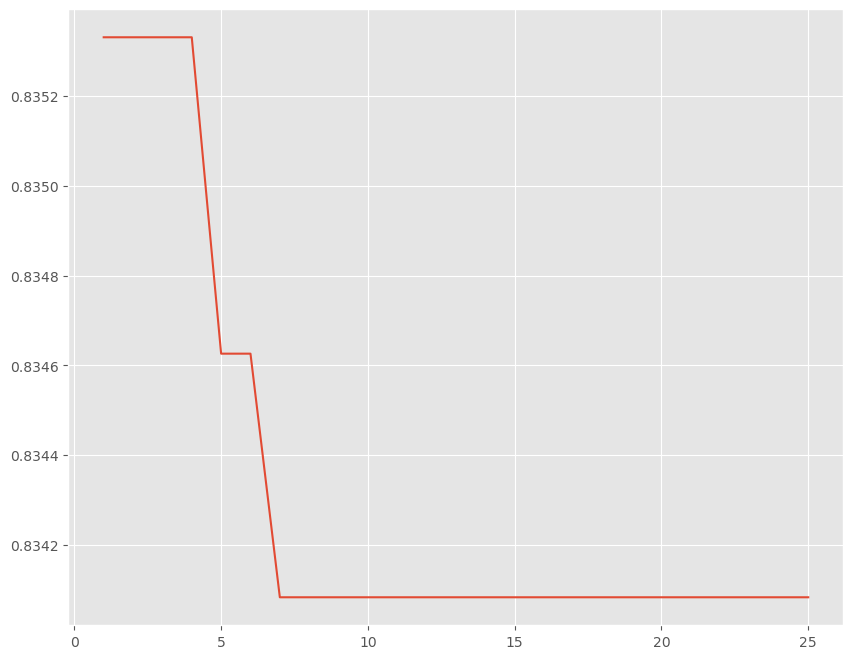

```python
plt.plot(trainAccuracy.groupby('depths').accuracy.mean())
```

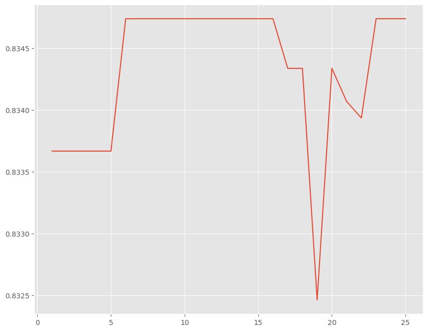

```python
plt.plot(trainAccuracy.groupby('splits').accuracy.mean().T)
```

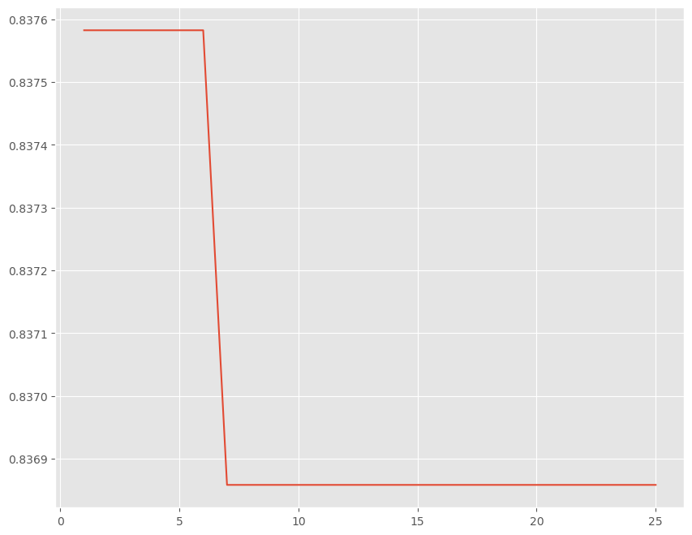

```python
plt.plot(validAccuracy.groupby('depths').accuracy.mean())
```

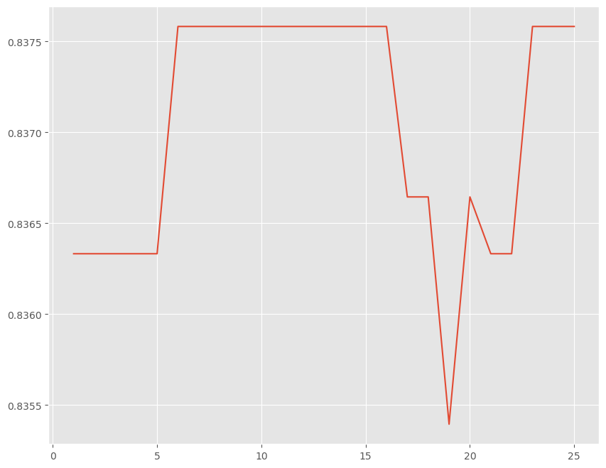

```python
plt.plot(validAccuracy.groupby('splits').accuracy.mean())
```

Известным фактом является то, что деревья решений сильно переобучаются при увеличении глубины и просто запоминают трейн. Замечаете ли вы такой эффект судя по графикам? Что при этом происходит с качеством на валидации?

## Находим самые важные признаки (2 балла)

По построенному дереву легко понять, какие признаки лучше всего помогли решить задачу. Часто это бывает нужно не только для сокращения размерности в данных, но и для лучшего понимания прикладной задачи. Например, Вы хотите понять, какие признаки стоит еще конструировать -- для этого нужно понимать, какие из текущих лучше всего работают в дереве.

Самый простой метод -- посчитать число сплитов, где использовался данные признак. Это не лучший вариант, так как по признаку который принимает всего 2 значения, но который почти точно разделяет выборку, число сплитов будет очень 1, но при этом признак сам очень хороший. В этом задании предлагается для каждого признака считать суммарный gain (в лекции обозначено как Q) при использовании этого признака в сплите. Тогда даже у очень хороших признаков с маленьким число сплитов это значение должно быть довольно высоким.

Реализовать это довольно просто: создаете словарь номер фичи : суммарный гейн и добавляете в нужную фичу каждый раз, когда используете ее при построении дерева.

Добавьте функционал, который определяет значения feature importance. Обучите дерево на датасете Speed Dating Data. Выведите 10 главных фичей по важности.

```python
features = np.array(df.loc[:, df.columns != 'match'].columns)
```

```python
features[my_clf.feature_importances_.argsort()]
```

```
array(['date', 'go_out', 'pid', 'intel1_1', 'shar2_1', 'imprelig',
       'sinc3_1', 'attr2_1', 'career_c', 'int_corr', 'intel2_1',
       'intel3_1', 'attr1_1', 'gender', 'race', 'field_cd', 'attr3_1',
       'goal', 'sinc2_1', 'amb3_1', 'imprace', 'fun2_1', 'samerace',
       'fun1_1', 'shar1_1', 'exphappy', 'amb2_1', 'age', 'amb1_1',
       'fun3_1', 'sinc1_1'], dtype=object)
```

## Фидбек (бесценно)

- Какие аспекты обучения деревьев решений Вам показались непонятными? Какое место стоит дополнительно объяснить?

- Здесь Вы можете оставить отзыв о этой домашней работе или о всем курсе.